# Python Bootcamp Day 1: Python Basics

Wanyi Wang (University of California Irvine, 2020 fall)

## 1. Preparation before class

### 1.1 Install Anaconda

- Download link: https://www.anaconda.com/products/individual
- We use **Python 3.8** version.
- It usually takes 20~30 mins to download and install, so please get it done before class.

**What is Anaconda?**

- A "one-stop" style Python distribution ("IKEA" in the world of programming languages).
- Easy to manage environments.
- Includes many common packages by default (similar to the “toolboxes” provided by IKEA).
- Especially helpful in data science and financial analysis.

### 1.2 Watch Jupyter Notebook Tutorial

- Link: https://www.youtube.com/watch?v=HW29067qVWk
- **Watch from 4:10 to 15:00.**
- You will know:
  - A brief introduction of the interface
  - What's command mode & Edit mode?
  - How to run/insert a cell (and shortcuts)?
  - What's the meaning of the number next to a cell?

```python
from IPython.lib.display import YouTubeVideo
YouTubeVideo('HW29067qVWk')
```

[video not shown]

**What is Jupyter Notebook?**

- An open-source web application
- allows you to create and share documents that contain:
  - live code
  - equations
  - visualizations
  - narrative text
- Uses include:
  - data cleaning and transformation
  - numerical simulation
  - statistical modeling
  - data visualization
  - machine learning

## 2. Introduction

### 2.1 What is Python?

**From Wikipedia:**

"Python is an interpreted, high-level, general-purpose `programming language`. Created by Guido van Rossum and first released in 1991, Python's design philosophy emphasizes code `readability` with its notable use of significant `whitespace`. Its language constructs and object-oriented approach aim to help programmers write clear, logical code for small and large-scale projects."

### 2.2 Why do we learn Python?

**Broadly speaking:**

- One of the most popular programming languages
- Open source, easy to use, and beginner friendly!
- A useful skill that can be written in your CV

**For your study in this program:**

- 240: Financial Research Methods (Professor Lu Zheng, 2021 Winter)
- 290: Fintech (Professor Jinfei Sheng, 2021 Spring)

So, why don't we learn Python?

### 2.3 What will we learn today?

- Variable and data type:
  - String
  - Number
  - Boolean value
- Control structure:
  - If statement
  - Loop: for loop, while loop
  - Loop: break, continue
- Data structure:
  - List
  - Dictionary

### 2.4 A good habit: write clear comments!

Comments are lines that will not be executed by Python. Comments are used to explain code to other developers (or yourself in the future). Comments starts with a hashtag (#).

```python
# This is a printing function.
print("Hello world!")
```

```
Hello world!
```

## 3. Variable and Data Type

Source: https://www.w3schools.com/python/

### Game 1: Mad libs (fill-in-the-blank)

```python
# Mad Lib example
print("BBQ at my house! Everyone's invited, and don't forget to bring your drinks!")
```

```
BBQ at my house! Everyone's invited, and don't forget to bring your drinks!
```

**How do you fill in the blank?**

```python
noun = "cat"
print("BBQ at my house! Everyone's invited, and don't forget to bring your", noun, "!")
```

```
BBQ at my house! Everyone's invited, and don't forget to bring your cat !
```

**Variables are containers for storing data values:**

*variable name* → `noun = "cat"` ← *variable value*

**Benefit of using variables:**

- Do not need to make revisions one by one if we change the code.
- Can use a lot of built-in functions.

**Key points about variables**:

- Unlike other programming languages, Python has no command for declaring a variable.
- A variable is created the moment you first assign a value to it.
- Variables do not need to be declared with any particular type and can even change type after they have been set.

**Variable Names:**

- A variable name cannot start with a number.
- A variable name can only contain alpha-numeric characters and underscores (A-z, 0-9, and _ ).
- Variable names are case-sensitive (age, AGE and and Age are three different variables).

**A good habit: Use descriptive and clear variable names.**

### 3.1 Strings

Strings in python are surrounded by either single quotation marks, or double quotation marks.

```python
string = 'Hello world!'
string = "Hello world!"
```

**Common built-in string functions:**

Function: a collection of code that does something.

Built-in functions: functions that are readily available in Python.

```python
string.upper()    # convert all letters to uppercase
```

```
'HELLO WORLD!'
```

```python
string.lower()    # convert all letters to lowercase
```

```
'hello world!'
```

```python
string.split(' ')  # split the string into substrings based on the separator
```

```
['Hello', 'world!']
```

```python
len("Hello world!") # the number of letters in a string(spaces and punctuations included)
```

```
12
```

```python
string.replace("world", "UCI")
```

```
'Hello UCI!'
```

### 3.2 Numbers

**Common numerical types:**

- Int, or integer, is a whole number, positive or negative, without decimals, of unlimited length.
- Float, or "floating point number" is a number, positive or negative, containing one or more decimals.

```python
abs(-25)     # absolute value
```

```
25
```

```python
pow(5,3)     # pow(a,b) = a to the power of b
```

```
125
```

```python
max(15,25)   # similarly, min(15,25) = 15
```

```
25
```

```python
round(-2.1)
```

```
-2
```

```python
# Type Conversion
number = "5"          # a string
print(int(number))    # an integer
print(float(number))  # a float
```

```
5
5.0
```

### 3.3 Boolean values

Booleans represent one of two values: True or False. In programming you often need to know if an expression is True or False.

```python
print(10 > 9)
```

```
True
```

```python
print(10 == 9)    # note the difference between "=" and "=="
```

```
False
```

```python
print(10 < 9)
```

```
False
```

### Exercise 1: Build your MAD LIBS game!✌️

```python
# example
print("You cannot enjoy a/an _____(adjective1) _____(noun1) without a/an _____(adjective2) _____(noun2).")
```

```
You cannot enjoy a/an _____(adjective1) _____(noun1) without a/an _____(adjective2) _____(noun2).
```

```python
# exercise
adj1 = input("Input adjective1:")
noun1 = input("Input noun1:")
adj2 = input("Input adjective2:")
noun2 = input("Input noun2:")

# please complete the code here to print out the entire sentence
print("You cannot enjoy a/an", adj1, noun1, "without a/an", adj2, noun2, ".")
```

```
Input adjective1:hot
Input noun1:shower
Input adjective2:yellow
Input noun2:duck
You cannot enjoy a/an hot shower without a/an yellow duck .
```

```python
print("a", "b")
```

```
a b
```

## 4. Control structure

**Game 2: Can you guess my number?**

- Rule: I have an integer between 1 and 100 in mind. You can guess it multiple times. I will tell you whether it's too large or too small until you get the right number.
- You'll be able to build your own number-guessing game after we learn this part.

### 4.1 If statement

*Scenario 1: "If it’s sunny today, I will go to Laguna beach."*

```python
# if statement
sunny = False
if sunny:
    print("Go to Laguna beach!🏄")   # notice the indentation
```

Note: "Most of the programming languages like C, C++, Java use curly brackets `{ }` to define a block of code. One of the distinctive features of Python is its use of `indentation` to highlight the blocks of code. Whitespace is used for indentation in Python."

*Scenario 2: "If it's sunny today, I will go to Laguna beach; otherwise, I will stay at home."*

```python
# if-else statement
sunny = False
if sunny:
    print("Go to Laguna beach!🏄")
else:
    print("Stay at home:(")
```

```
Stay at home:(
```

*Scenario 3: "If it’s sunny today, I will go to Laguna beach; if it's cloudy, I will go shopping; otherwise, I will stay at home."*

```python
# if-elif-else statement
sunny = False
cloudy = True
if sunny:
    print("Head to Laguna beach!🏄")
elif cloudy:
    print("Go shopping!!！💰")
else:
    print("Stay at home:(")
```

```
Go shopping!!！💰
```

*Scenario 4: "If it’s sunny today and I have no homework to do, I will go to Laguna beach."*

```python
# multiple conditions
sunny = True
homework = True
if sunny and not homework:      # not is used to negate the variable after it
    print("Go to Laguna beach!🏄")
```

**Towards building a number-guessing game...🤔**

```python
# if statement and comparison operators
answer = 53
number = 46
if number > answer:
    print("The number you input is too large!")
elif number < answer:
    print("The number you input is too small!")
elif number == answer:      # "a == b" means "a equals to b". "a = b" means "let a be b".
    print("Exactly! You got the right answer!")
# other comparison operators: >=, <=, !=
```

```
The number you input is too small!
```

### 4.2 Loop: For loop

Loop is used when we want to execute a block of code for a certain amount of times. A for loop is used for iterating over a sequence (of numbers, words, strings, etc.)

```python
# loop through letters inside of a string
for i in "Python":
    print(i)           # i is called the "iterator"
```

```
P
y
t
h
o
n
```

```python
# loop through a sequence of numbers
for i in range(10):      # range(n) = 0,1,2,...,n-1
    print(i)
```

```
0
1
2
3
4
5
6
7
8
9
```

```python
# Nested loop:
for i in range(1,4):     # range(a,b) = a,a+1,...,b-2,b-1.
    for j in range(1,4):
        print(str(i)+" x "+str(j)+" = "+ str(i*j))    # print a multiplication table
```

```
1 x 1 = 1
1 x 2 = 2
1 x 3 = 3
2 x 1 = 2
2 x 2 = 4
2 x 3 = 6
3 x 1 = 3
3 x 2 = 6
3 x 3 = 9
```

### 4.3 Loop: While loop

In python, while loop is used to execute a block of statements repeatedly **until a given a condition is `NOT` satisfied**. When the condition becomes false, the loop will be ended, and the line immediately after the loop in program will be executed.

```python
i = 0
while i < 6:
    print("i =", i)
    i = i + 1
print("i =", i, "Loop finished!")
```

```
i = 0
i = 1
i = 2
i = 3
i = 4
i = 5
i = 6 Loop finished!
```

While loop can be pretty useful when you don't know how many times the loop will be executed.

### 4.4 Loop: Break & continue

In Python, break and continue statements can alter the flow of a normal loop.

Source: https://www.programiz.com/python-programming/break-continue

#### 4.4.1 Break statement

The break statement terminates the loop containing it. Control of the program jumps to the code immediately after the loop.

```python
# Example
i = 0

while 1:
    print(i)
    i = i + 1
    if i >= 6:
        break

print("Done!")
```

```
0
1
2
3
4
5
Done!
```

#### 4.4.2 Continue statement

The continue statement is used to skip the rest of the code inside a loop **for the current iteration only**. Loop does not terminate but continues on with the next iteration.

```python
# Example: print out numbers not divisible by 3
for i in range(6):      # range(n) = 0,1,2,...,n-1
    if i % 3 == 0:
        continue
    print(i)            # note that 0 and 3 are not printed
```

```
1
2
4
5
```

### Exercise 2: Build your number-guessing game✌️

```python
import random
answer = random.randint(1,100)
number = 0

while answer != number:
    number = input("Enter a number:")
    number = int(number)
    if number < answer:
        print("The number you input is too small!")
    elif number > answer:
        print("The number you input is too large!")

print("Congrats! You got the right answer!")
```

```
Enter a number:57
The number you input is too small!
Enter a number:87
The number you input is too large!
Enter a number:70
The number you input is too large!
Enter a number:63
The number you input is too large!
Enter a number:60
The number you input is too large!
Enter a number:59
The number you input is too large!
Enter a number:58
Congrats! You got the right answer!
```

## 5. Data structure: List and Dictionary

We often need to manage and organize a large amount of data, so we need data structures.

Four data structures in Python:

- List √
- Dictionary √
- Tuple
- Set

**Game 3: Can you decode my secret word?😜**

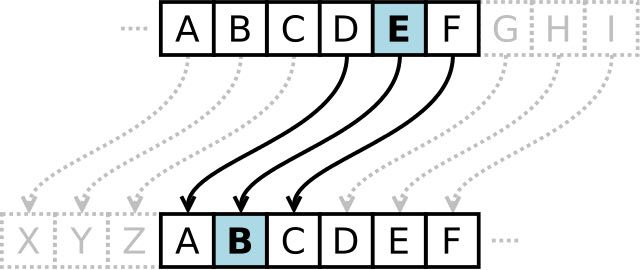

- Online encoder/decoder: https://www.xarg.org/tools/caesar-cipher/

### 5.1 List

A list is a data structure that is a mutable, or changeable, ordered sequence of elements. Each element or value that is inside of a list is called an item. Lists are defined by square brackets [ ].

```python
# Examples

# a list of strings
Name = ["Alex", "Betty", "Catherine", "David", "Elizabeth"]

# a list of numbers
LuckyNumber = [4, 7, 2, 24, 9]

# a list can take multiple data types
Mixed = ["Alex", 4, True, 3.5]
```

**Common List Functions**

#### 5.1.1 Access items in a list

```python
Name[2]           # Always remember that Python starts indexing from ZERO!
```

```
'Catherine'
```

```python
# Can indexes be negative?
Name[-1]          # the last item in the list
```

```
'Elizabeth'
```

```python
# Access a subset of a list (slicing)

print(Name[1:3])
# [1:3] -> [1,3). A left-closed, right-open interval

print(Name[1:])   # [1:]  -> [1,end]
```

```
['Betty', 'Catherine']
['Betty', 'Catherine', 'David', 'Elizabeth']
```

```python
# Access a subset of a list (step size = 2)
Name[0:5:2]
```

```
['Alex', 'Catherine', 'Elizabeth']
```

```python
# Access a subset of a list (reverse order)
Name[5::-1]
```

```
['Elizabeth', 'David', 'Catherine', 'Betty', 'Alex']
```

#### 5.1.2 Change/add/delete items in a list:

```python
# change the 3rd item
Name[2] = "Chelsea"
Name
```

```
['Alex', 'Betty', 'Chelsea', 'David', 'Elizabeth']
```

```python
# Add an item at the end of a list
Name.append("Frank")
Name
```

```
['Alex', 'Betty', 'Chelsea', 'David', 'Elizabeth', 'Frank']
```

```python
# Insert a new item before the 6th item
Name.insert(5, "Elsa")
Name
```

```
['Alex', 'Betty', 'Chelsea', 'David', 'Elizabeth', 'Elsa', 'Frank']
```

```python
# remove item from the list
Name.remove("Betty")
Name
```

```
['Alex', 'Chelsea', 'David', 'Elizabeth', 'Elsa', 'Frank']
```

#### 5.1.3 Search for an item in a list:

```python
Name.index("Frank")      # return the index of "Frank"
```

```
5
```

```python
Name.index("Kate")       # What if the item is not in the list?
```

```
---------------------------------------------------------------------------
ValueError                                Traceback (most recent call last)
<ipython-input-45-796b24f3311b> in <module>
----> 1 Name.index("Kate")       # What if the item is not in the list?

ValueError: 'Kate' is not in list
```

```python
LuckyNumber.sort()
LuckyNumber
```

```
[2, 4, 7, 9, 24]
```

```python
LuckyNumber.reverse()
LuckyNumber
```

```
[24, 9, 7, 4, 2]
```

### 5.2 Dictionary

Python dictionary is an unordered collection of items. While other compound data types have only value as an element, a dictionary stores items in `key-value` pairs. A dictionary is defined by a pair of curly brackets.

```python
# Use a pair of curly brackets to define a dictionary. Use colon to declare key-value pairs.
LuckyDict = {'Alex': 24,
             'Betty': 9,
             'Catherine': 7,
             'David': 4,
             'Elizabeth': 2}
print(LuckyDict)
```

```
{'Alex': 24, 'Betty': 9, 'Catherine': 7, 'David': 4, 'Elizabeth': 2}
```

**Important properties:**

- Values can be duplicated, but keys need to be unique.
- values are mutable, but keys are immutable.
- Dictionary is unordered.

```python
# If keys are duplicated, the latter value will be memorized
LuckyDict2 = {'Alex': 24,
             'Betty': 9,
             'Catherine': 7,
             'David': 4,
             'Alex': 2}
LuckyDict2
```

```
{'Alex': 2, 'Betty': 9, 'Catherine': 7, 'David': 4}
```

```python
# Dictionary is unordered
Dict1 = {'a': 2, 'b': 3, 'c': 5}
Dict2 = {'c': 5, 'b': 3, 'a': 2}
print(Dict1 == Dict2)
```

```
True
```

**Common dictionary functions**

#### 5.2.1 Access items in a dictionary

```python
LuckyDict['Alex']      # return the value whose key is 'Alex'
```

```
24
```

```python
LuckyDict.get('Alex')
```

```
24
```

#### 5.2.2 Change/add/delete items in a dictionary

When k is in the dictionary, "d[k] = x" means "set the value with key k to x".

```python
LuckyDict['Catherine'] = 10
LuckyDict
```

```
{'Alex': 24, 'Betty': 9, 'Catherine': 10, 'David': 4, 'Elizabeth': 2}
```

When k is not in the dictionary, "d[k] = x" means "add a key-value pair (k,x)".

```python
LuckyDict['Gordon'] = 6
LuckyDict
```

```
{'Alex': 24,
 'Betty': 9,
 'Catherine': 10,
 'David': 4,
 'Elizabeth': 2,
 'Gordon': 6}
```

```python
del LuckyDict['David']          # delete the item whose key is 'David'
LuckyDict
```

```
{'Alex': 24, 'Betty': 9, 'Catherine': 10, 'Elizabeth': 2, 'Gordon': 6}
```

#### 5.2.3 Search for an item in a dictionary

```python
'Alex' in LuckyDict
```

```
True
```

```python
'Franklin' in LuckyDict
```

```
False
```

```python
LuckyDict.keys()    # return all keys
```

```
dict_keys(['Alex', 'Betty', 'Catherine', 'Elizabeth', 'Gordon'])
```

```python
LuckyDict.values()  # return all values
```

```
dict_values([24, 9, 10, 2, 6])
```

```python
LuckyDict.items()   # return all key-value pairs
```

```
dict_items([('Alex', 24), ('Betty', 9), ('Catherine', 10), ('Elizabeth', 2), ('Gordon', 6)])
```

**Exercise: Build your own word decoder!✌️**

```python
# using dictionary
puzzle = "QEXKHPDFSFKD"

Map = {'A':'D', 'B':'E', 'C':'F', 'D':'G', 'E':'H', 'F':'I', 'G':'J',
       'H':'K', 'I':'L', 'J':'M', 'K':'N', 'L':'O', 'M':'P', 'N':'Q',
       'O':'R', 'P':'S', 'Q':'T', 'R':'U', 'S':'V', 'T':'W', 'U':'W',
       'V':'Y','W':'Z', 'X':'A', 'Y':'B', 'Z':'C'}

answer = ""

for letter in puzzle:
    answer = answer + Map[letter]

print(answer)
```

```
THANKSGIVING
```

```python
# using list (a simpler & smarter way)
puzzle = "QEXKHPDFSFKD"

List = "ABCDEFGHIJKLMNOPQRSTUVWXYZ"

offset = 3

answer = ""
for letter in puzzle:
    index = List.index(letter)
    answer = answer + List[(index + offset)%26]

print(answer)
```

```
THANKSGIVING
```

**Background: Caesar cipher**

In cryptography, a Caesar cipher is one of the simplest and most widely known encryption techniques. The Caesar cipher is named after *Julius Caesar*, a Roman general and statesman who played a critical role in the events that led to the demise of the Roman Republic and the rise of the Roman Empire.

**Bonus:**

- puzzle = "VODDM HVOBYGUWJWBU"
- Offset unknown!
- What is the answer?

### To learn more:

```python
YouTubeVideo('rfscVS0vtbw')
```

[video not shown]

A website: https://www.mikedane.com/programming-languages/python/

- Self-paced learning
- Section by section
- Video & narratives